# Statistical Inference Course Project (Part 2)

Jeffrey M. Hunter

21 May, 2019

## Course Project

**Statistical Inference Course Project**

Peer-graded Assignment

- This course project is available on GitHub

  [Statistical Inference Course Project](https://github.com/oraclejavanet/statistical-inference-course-project-1)

## Synopsis

In this second part of a two-part project assignment, we are being asked to investigate the effect of vitamin C on tooth growth in guinea pigs.

This analysis will compare the effects of different doses of vitamin C using two delivery methods to study the tooth growth in guinea pigs. The sample will consist of 60 guinea pigs. Each guinea pig will receive one of three dose levels of vitamin C (0.5, 1, and 2 mg/day) by one of two delivery methods, orange juice or ascorbic acid supplements.

The study will be performed using the ToothGrowth dataset which is included in the R `datasets` package. The dataset is a data frame that contains 60 observations and 3 variables:

- len - A numeric vector indicating the measurement of tooth length after vitamin C delivery
- supp - A factor vector describing the delivery method used: Orange Juice (OJ) or Ascorbic Acid (VC)
- dose - A numeric vector indicating the dosage level in milligrams per day (0.5, 1, or 2mg)

Further information on the ToothGrowth dataset can be found in the R documentation using `?ToothGrowth`.

## Environment Setup

Load packages used in this analysis.

```r
if (!require(ggplot2)) {
    install.packages("ggplot2")
    library(ggplot2)
}
```

## Basic Data Summary

After loading the ToothGrowth dataset, provide a basic summary of the data.

```r
str(ToothGrowth)
```

```
## 'data.frame':    60 obs. of  3 variables:
##  $ len : num  4.2 11.5 7.3 5.8 6.4 10 11.2 11.2 5.2 7 ...
##  $ supp: Factor w/ 2 levels "OJ","VC": 2 2 2 2 2 2 2 2 2 2 ...
##  $ dose: num  0.5 0.5 0.5 0.5 0.5 0.5 0.5 0.5 0.5 0.5 ...
```

```r
summary(ToothGrowth)
```

```
##       len        supp         dose
##  Min.   : 4.20   OJ:30   Min.   :0.500
##  1st Qu.:13.07   VC:30   1st Qu.:0.500
##  Median :19.25           Median :1.000
##  Mean   :18.81           Mean   :1.167
##  3rd Qu.:25.27           3rd Qu.:2.000
##  Max.   :33.90           Max.   :2.000
```

```r
# tabulate delivery method and dosage level values
table(ToothGrowth$supp, ToothGrowth$dose)
```

```
##
##      0.5  1  2
##   OJ  10 10 10
##   VC  10 10 10
```

```r
# summary of tooth length data grouped by delivery method and dosage level
by(data = ToothGrowth$len, INDICES = list(ToothGrowth$supp, ToothGrowth$dose), summary)
```

```
## : OJ
## : 0.5
##    Min. 1st Qu.  Median    Mean 3rd Qu.    Max.
##    8.20    9.70   12.25   13.23   16.18   21.50
## --------------------------------------------------------
## : VC
## : 0.5
##    Min. 1st Qu.  Median    Mean 3rd Qu.    Max.
##    4.20    5.95    7.15    7.98   10.90   11.50
## --------------------------------------------------------
## : OJ
## : 1
##    Min. 1st Qu.  Median    Mean 3rd Qu.    Max.
##   14.50   20.30   23.45   22.70   25.65   27.30
## --------------------------------------------------------
## : VC
## : 1
##    Min. 1st Qu.  Median    Mean 3rd Qu.    Max.
##   13.60   15.28   16.50   16.77   17.30   22.50
## --------------------------------------------------------
## : OJ
## : 2
##    Min. 1st Qu.  Median    Mean 3rd Qu.    Max.
##   22.40   24.57   25.95   26.06   27.07   30.90
## --------------------------------------------------------
## : VC
## : 2
##    Min. 1st Qu.  Median    Mean 3rd Qu.    Max.
##   18.50   23.38   25.95   26.14   28.80   33.90
```

## Exploratory Data Analysis

Perform some basic exploratory data analyses of the data. The analyses will explore the following relations:

1. Tooth Length (len) as a function of Delivery Method (supp)
2. Tooth Length (len) as a function of Dosage Level (dose)
3. Tooth Length (len) as a function of Delivery Method (supp) and Dosage Level (dose)

### Tooth Length to Delivery Method

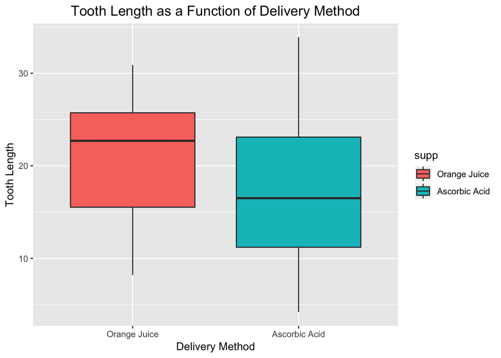

```r
tg <- ToothGrowth
levels(tg$supp) <- c("Orange Juice", "Ascorbic Acid")
gLenSupp <- ggplot(data = tg, aes(x = supp, y = len)) +
    geom_boxplot(aes(fill = supp)) +
    xlab("Delivery Method") +
    ylab("Tooth Length") +
    theme(plot.title = element_text(size = 14, hjust = 0.5)) +
    ggtitle("Tooth Length as a Function of Delivery Method")
print(gLenSupp)
```

**Observation**

The above chart shows that using orange juice as the delivery method, independent of dosage level, had a more favorable effect on tooth growth than ascorbic acid.

### Tooth Length to Dosage Level

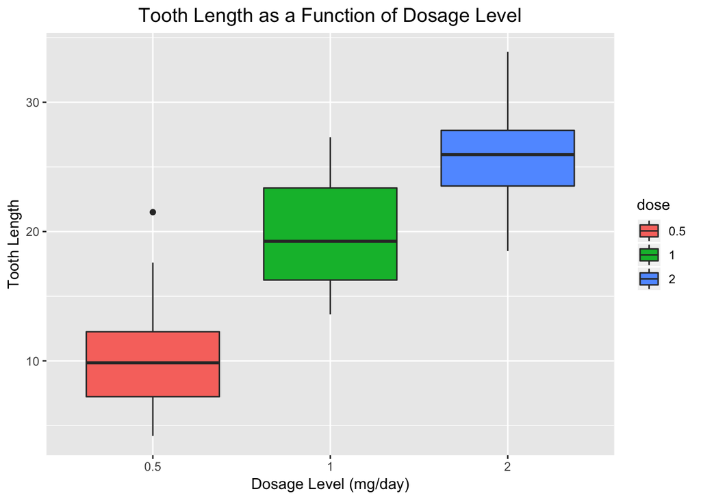

```r
gLenDose <- ggplot(data = ToothGrowth, aes(x = factor(dose), y = len)) +
    geom_boxplot(aes(fill = factor(dose))) +
    xlab("Dosage Level (mg/day)") +
    ylab("Tooth Length") +
    guides(fill=guide_legend(title="dose")) +
    theme(plot.title = element_text(size = 14, hjust = 0.5)) +
    ggtitle("Tooth Length as a Function of Dosage Level")
print(gLenDose)
```

**Observation**

The above chart shows a positive relationship that higher dosage levels of vitamin C, independent of delivery method, had a more favorable effect on tooth growth than lower dosages of vitamin C. The 2 mg/day dosage level had the best effect on tooth growth followed by 1 mg/day and then 0.5 mg/day.

### Tooth Length to Delivery Method and Dosage Level

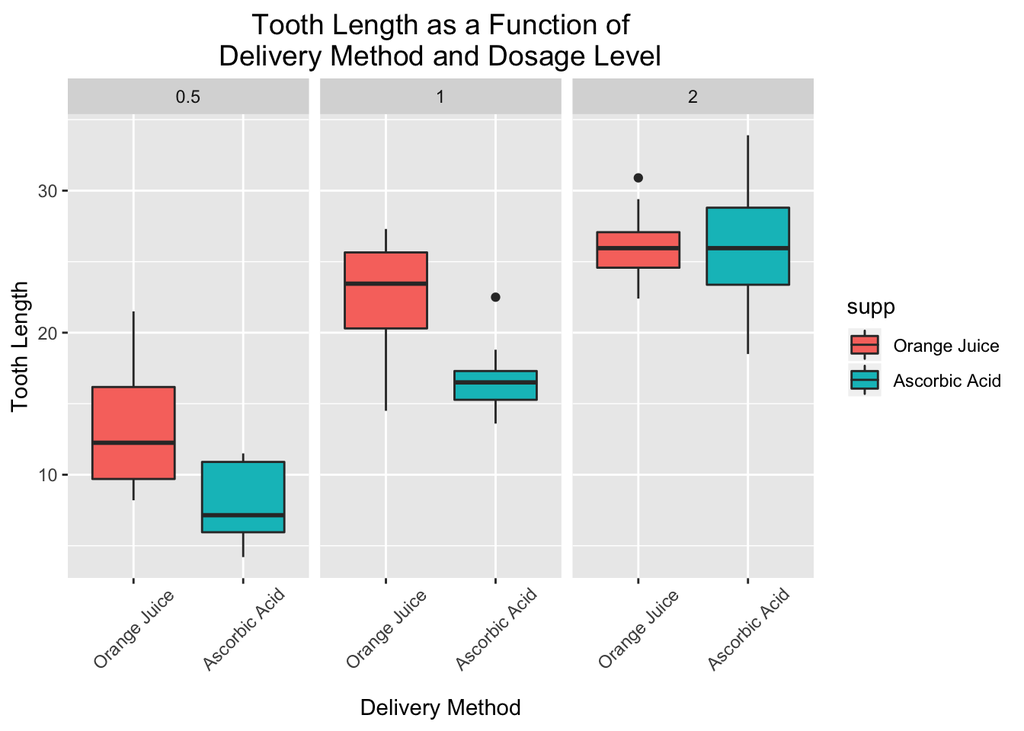

```r
tg <- ToothGrowth
levels(tg$supp) <- c("Orange Juice", "Ascorbic Acid")
gLenSuppDose <- ggplot(data = tg, aes(x = supp, y = len)) +
    geom_boxplot(aes(fill = supp)) +
    facet_wrap(~ dose) +
    xlab("Delivery Method") +
    ylab("Tooth Length") +
    guides(fill=guide_legend(title="supp")) +
    theme(plot.title = element_text(size = 14, hjust = 0.5, vjust = 0.5),
          axis.text.x = element_text(angle = 45,
                                     hjust = 0.5,
                                     vjust = 0.5,
                                     margin = margin(b = 10))) +
    ggtitle("Tooth Length as a Function of\nDelivery Method and Dosage Level")
print(gLenSuppDose)
```

**Observation**

Looking at the above chart which shows tooth growth as a function of delivery method and dosage level, it appears that orange juice is more effective than ascorbic acid as the delivery method when the dosage level is 0.5 to 1 mg/day. The higher dosage level of 2 mg/day is more effective than the lower dosages; however, both delivery methods are equally as effective.

## Inferential Statistics

Exploratory data analysis is helpful to study and visually interrogate data; however, the use of inferential statistics allows us to use techniques such as the confidence interval and/or hypothesis testing to more precisely draw conclusions about a population from which representative samples were taken.

In this section, hypothesis testing will be employed to study the impact of delivery method (orange juice and ascorbic acid supplements) and dosage level on tooth growth. A p-value less than or greater than a significance level of 5% will be used as the threshold to reject or accept the null hypothesis.

### Hypothesis 1

Hypothesis testing will be conducted to study the impact of delivery method on tooth growth, independent of dosage level. A t-test will be performed on the null hypothesis that the two delivery methods have no effect on tooth growth.

```r
t1 <- t.test(len ~ supp, data = ToothGrowth, conf.level = 0.95)
paste0("p-value = ", round(t1$p.value, 4))
```

```
## [1] "p-value = 0.0606"
```

```r
paste0("confidence interval = (", round(t1$conf.int[1], 4) , ", ", round(t1$conf.int[2], 4), ")")
```

```
## [1] "confidence interval = (-0.171, 7.571)"
```

The observed p-value 0.0606 is greater than 0.05 and the 95% confidence interval contains zero. This indicates weak evidence against the null hypothesis so we fail to reject the null hypothesis.

### Hypothesis 2

Hypothesis testing will be conducted to study the impact of delivery method on tooth growth for a single dosage level. A t-test will be performed on the null hypothesis that the two delivery methods at a dosage level of 0.5 mg/day have no effect on tooth growth.

```r
t2 <- t.test(len ~ supp, data = subset(ToothGrowth, dose == 0.5), conf.level = 0.95)
paste0("p-value = ", round(t2$p.value, 4))
```

```
## [1] "p-value = 0.0064"
```

```r
paste0("confidence interval = (", round(t2$conf.int[1], 4) , ", ", round(t2$conf.int[2], 4), ")")
```

```
## [1] "confidence interval = (1.7191, 8.7809)"
```

The observed p-value 0.0064 is less than 0.05 and the 95% confidence interval does not contain zero. This indicates strong evidence against the null hypothesis so the null hypothesis can be rejected.

### Hypothesis 3

Hypothesis testing will be conducted to study the impact of delivery method on tooth growth for a single dosage level. A t-test will be performed on the null hypothesis that the two delivery methods at a dosage level of 1 mg/day have no effect on tooth growth.

```r
t3 <- t.test(len ~ supp, data = subset(ToothGrowth, dose == 1), conf.level = 0.95)
paste0("p-value = ", round(t3$p.value, 4))
```

```
## [1] "p-value = 0.001"
```

```r
paste0("confidence interval = (", round(t3$conf.int[1], 4) , ", ", round(t3$conf.int[2], 4), ")")
```

```
## [1] "confidence interval = (2.8021, 9.0579)"
```

The observed p-value 0.001 is less than 0.05 and the 95% confidence interval does not contain zero. This indicates strong evidence against the null hypothesis so the null hypothesis can be rejected.

### Hypothesis 4

Hypothesis testing will be conducted to study the impact of delivery method on tooth growth for a single dosage level. A t-test will be performed on the null hypothesis that the two delivery methods at a dosage level of 2 mg/day have no effect on tooth growth.

```r
t4 <- t.test(len ~ supp, data = subset(ToothGrowth, dose == 2), conf.level = 0.95)
paste0("p-value = ", round(t4$p.value, 4))
```

```
## [1] "p-value = 0.9639"
```

```r
paste0("confidence interval = (", round(t4$conf.int[1], 4) , ", ", round(t4$conf.int[2], 4), ")")
```

```
## [1] "confidence interval = (-3.7981, 3.6381)"
```

The observed p-value 0.9639 is greater than 0.05 and the 95% confidence interval contains zero. This indicates weak evidence against the null hypothesis so we fail to reject the null hypothesis.

## Conclusion

This analysis employed the use of statistical inference to compare the effects of different dosage levels of vitamin C using two delivery methods to study the tooth growth in guinea pigs.

### Assumptions

- Tooth growth follows a normal distribution.
- The two variables, dosage levels and delivery method, are independent and identically distributed.
- No other confounding factors were included that would effect tooth growth.
- The population was comprised of similar guinea pigs.
- A p-value less than or greater than a significance level of 5% will be used as the threshold to reject or accept the null hypothesis.